# Дискретно-событийное моделирование

Лабораторная работа №7

Тарасова Алина Андреевна

1132236013@rudn.ru

Российский университет дружбы народов

2026-05-10

# Информация

## Докладчик

- Тарасова Алина Андреевна
- студентка
- Российский университет дружбы народов им. П. Лумумбы
- 1132236013@rudn.ru

# Вводная часть

## Актуальность

- Дискретно-событийное моделирование широко применяется для анализа систем массового обслуживания
- Модели M/M/c и Росса позволяют оценивать производительность и надёжность реальных систем
- Важно уметь реализовывать такие модели программно и интерпретировать результаты

## Объект и предмет исследования

- **Объект:** системы массового обслуживания
- **Предмет:** дискретно-событийное моделирование моделей M/M/c и Росса на языке Julia

## Цели и задачи

- Освоить метод дискретно-событийного моделирования
- Реализовать модели M/M/c и Росса на Julia
- Провести параметрические исследования
- Построить графики и сравнить с аналитикой

## Материалы и методы

- Язык программирования Julia
- Пакеты: `ConcurrentSim`, `ResumableFunctions`, `Distributions`, `Plots`, `Literate`, `DrWatson`
- Quarto для генерации отчётов и презентаций

# Создание презентации

## Процессор `quarto`

- Quarto: универсальный издательский инструмент
- Поддержка Julia, Python, R
- Создание PDF, HTML, DOCX

## Формат `pdf`

- Использование LaTeX
- Пакет для презентации: beamer
- Автоматическая компиляция через `quarto render`

## Код для формата `pdf`

```yaml
format:
  beamer:
    theme: metropolis
    aspectratio: 169
    slide-level: 2
```

## Формат `html`

- Используется фреймворк reveal.js
- Интерактивная презентация
- Поддержка анимации и переходов

## Код для формата `html`

```yaml
format:
  revealjs:
    theme: beige
    slide-number: true
```

# Выполнение лабораторной работы

## 1. Создание нового релиза

- Создан релиз v.7.0.0 для лабораторной работы №7

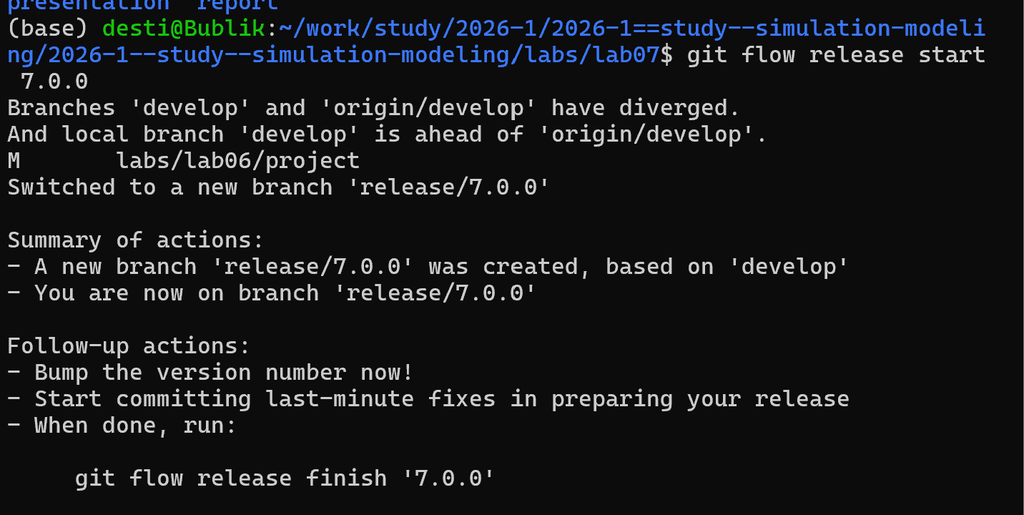

Рисунок 1

## 2. Настройка окружения Julia

- Запуск Julia и установка пакетов

[figure not shown]

Рисунок 2

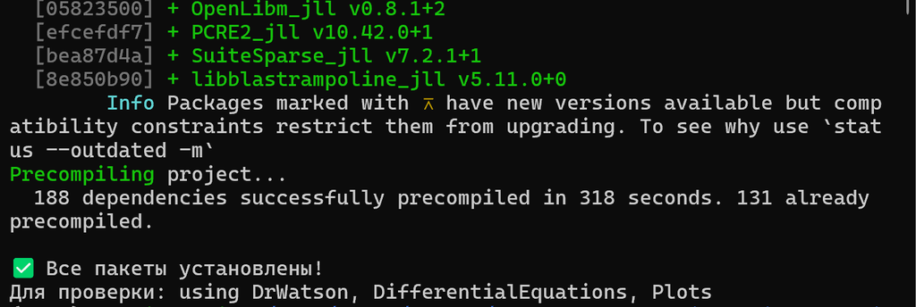

Рисунок 3

## 3. Установка пакетов для скриптов

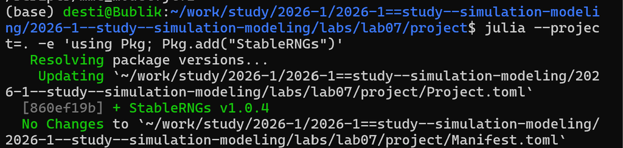

Рисунок 4

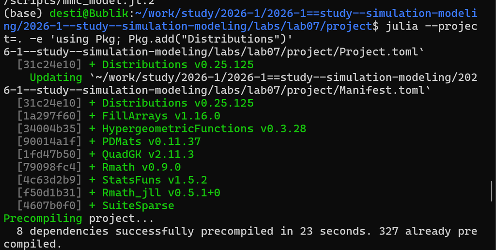

Рисунок 5

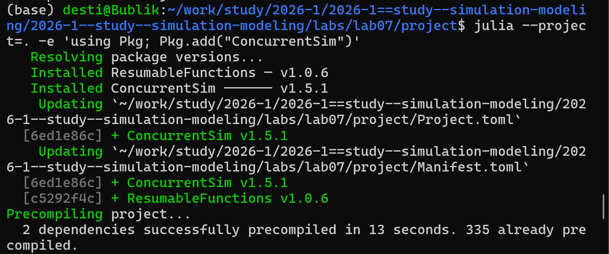

Рисунок 6

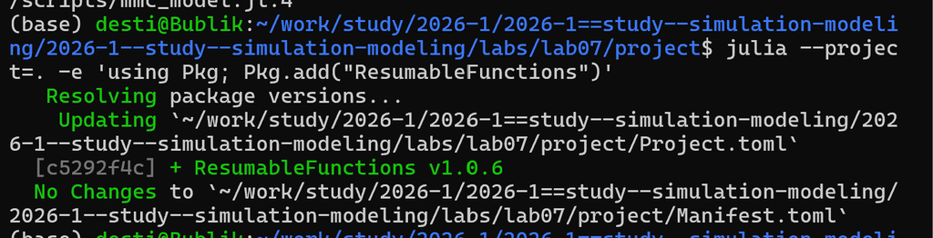

Рисунок 7

## 4. Запуск модели M/M/c

- Запуск скрипта `scripts/mmc_model.jl`

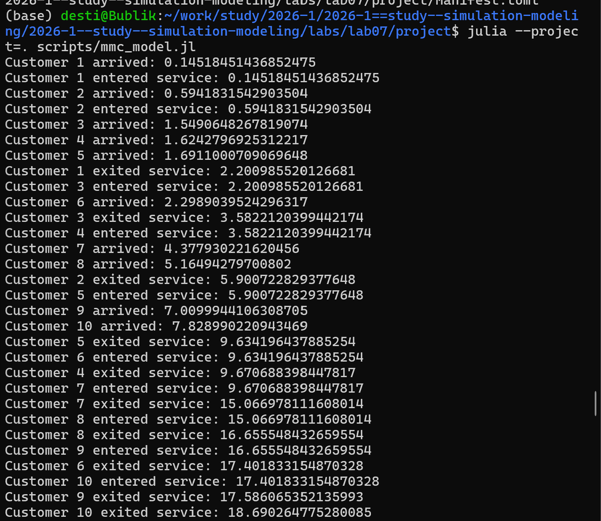

Рисунок 8

- Создан Jupyter Notebook для модели M/M/c

[figure not shown]

Рисунок 9

## 5. Запуск модели Росса

- Запуск скрипта `scripts/ross_model.jl`

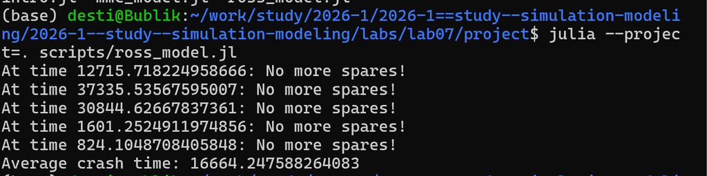

Рисунок 10

- Создан Jupyter Notebook для модели Росса

[figure not shown]

Рисунок 11

## 6. Создание производных форматов

- Генерация чистого кода, Notebook и Quarto-документов

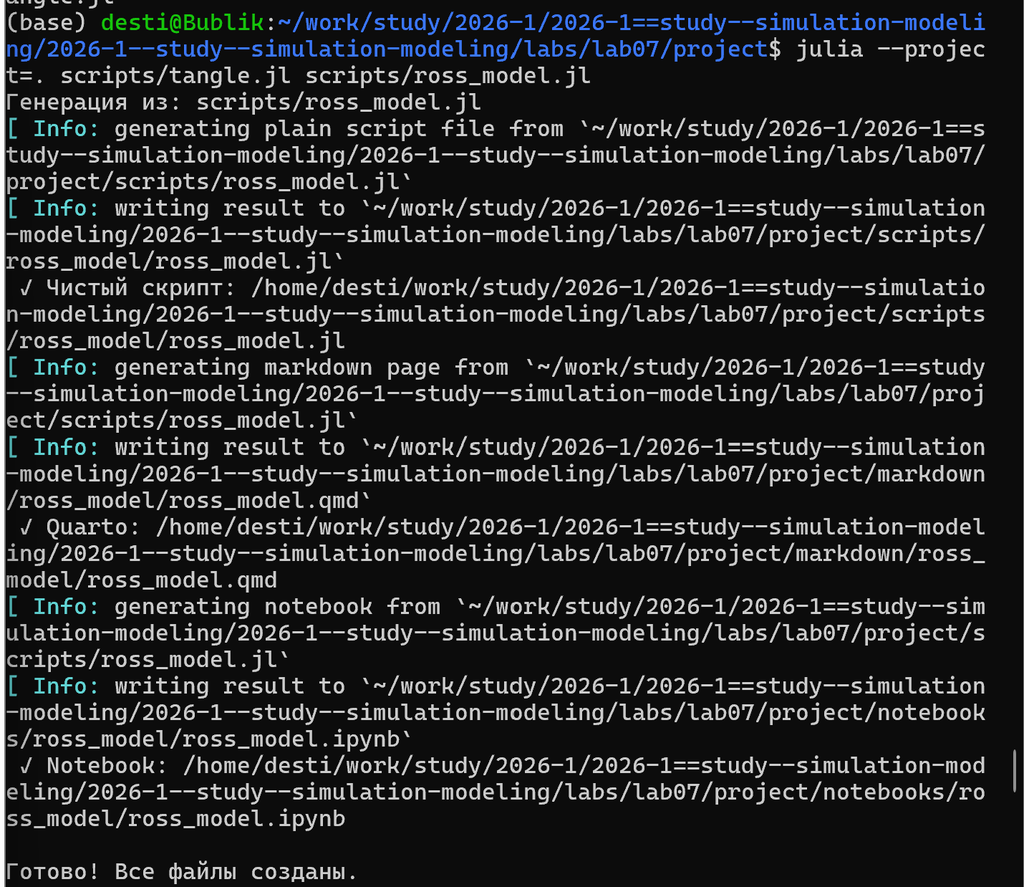

Рисунок 12

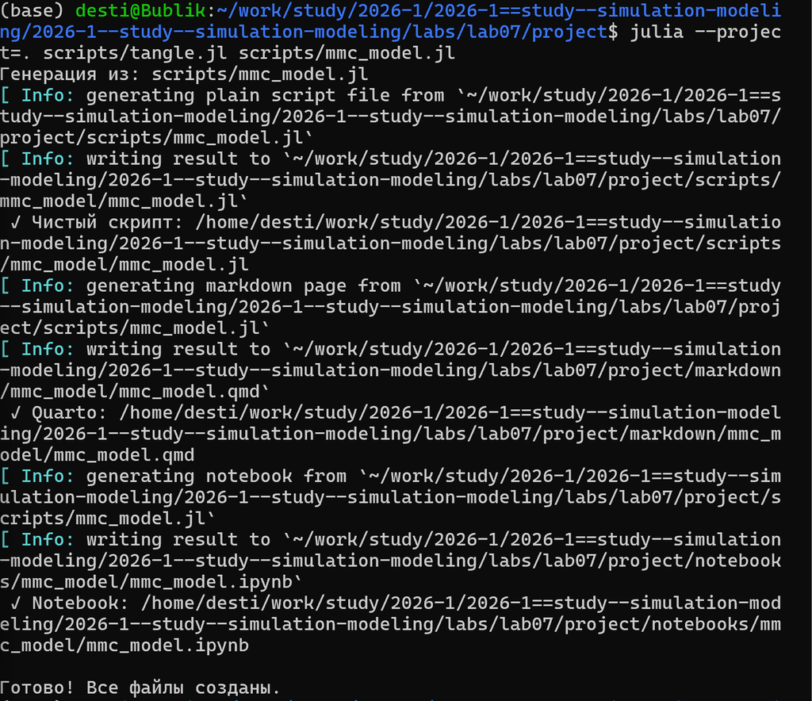

Рисунок 13